# Customer_report

### CUSTOMER REPORT (MARKET INSIGHT ANALYSIS)

Date: 07/03/2023

#### Hemant Thapa

For example, the customer's address, age, employer, and marital status can give an idea of their demographic profile and help in segmenting the customers based on their characteristics. The information about the credit card, bank IBAN, and yearly salary can be used to understand the customer's spending habits and financial status. The information about the distance commuted to work, dependants, and pension can give an idea of the customer's income and expenses.

By analyzing this data, businesses can make informed decisions about how to target and engage with their customers, and what products or services they are most likely to be interested in. Additionally, this analysis can also help identify potential risk factors associated with a customer, such as a high credit card debt or a low salary, which can be addressed through targeted interventions.

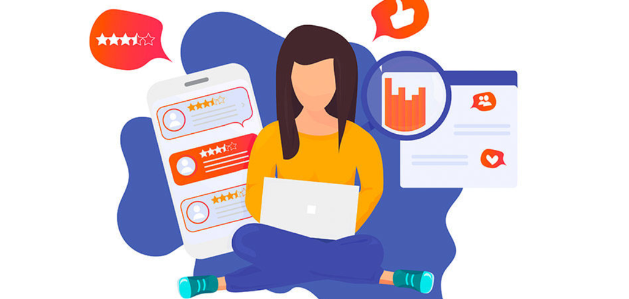

### 1. IMPORTING LIBRARIES

```python
import pandas as pd
import numpy as np
import matplotlib.pyplot as plt
import os
import random
import re
import seaborn as sns
import missingno as msno
from geopy.geocoders import Nominatim
from geopy.exc import GeocoderTimedOut
import geopandas as gpd
import folium
from mpl_toolkits.mplot3d import Axes3D
import matplotlib.pyplot as plt
import plotly.express as px
```

### 2. LOADING DATASET

```python
df = pd.read_csv(r'acw_user_data.csv', delimiter=',')
df[0:]
```

|  | Address Street | Address City | Address Postcode | Age (Years) | Distance Commuted to Work (miles) | Employer Company | Credit Card Start Date | Credit Card Expiry Date | Credit Card Number | Credit Card CVV | ... | Last Name | Marital Status | Yearly Pension (£) | Retired | Yearly Salary (£) | Sex | Vehicle Make | Vehicle Model | Vehicle Year | Vehicle Type |
| --- | --- | --- | --- | --- | --- | --- | --- | --- | --- | --- | --- | --- | --- | --- | --- | --- | --- | --- | --- | --- | --- |
| 0 | 70 Lydia isle | Lake Conor | S71 7XZ | 89 | 0.00 | NaN | 08/18 | 11/27 | 676373692463 | 875 | ... | Wilson | married or civil partner | 7257 | True | 72838 | Male | Hyundai | Bonneville | 2009 | Pickup |
| 1 | 00 Wheeler wells | Chapmanton | L2 7BT | 46 | 13.72 | Begum-Williams | 08/12 | 11/26 | 4529436854129855 | 583 | ... | Thomas | married or civil partner | 0 | False | 54016 | Male | Nissan | ATS | 1996 | Coupe |
| 2 | Studio 33K Joel walk | Randallborough | ME3N 1GH | 22 | 16.02 | Hill-Wright | 11/19 | 07/27 | 4091726363083888495 | 422 | ... | Jones | married or civil partner | 0 | False | 68049 | Male | GMC | Achieva | 2015 | Convertible, Coupe |
| 3 | Studio 46S Bethany lights | East Reece | E10 9RJ | 56 | 19.35 | Green LLC | 10/17 | 04/18 | 4671332769487632633 | 669 | ... | Shaw | married or civil partner | 0 | False | 91337 | Male | Scion | F150 SuperCrew Cab | 1994 | Pickup |
| 4 | Flat 3 Christine views | Fletcherstad | WS2 9SN | 57 | 5.94 | Hill, Evans and Harrison | 04/19 | 11/27 | 2245094149128526 | 659 | ... | O'Brien | married or civil partner | 0 | False | 18446 | Female | Buick | Outback | 2020 | SUV |
| ... | ... | ... | ... | ... | ... | ... | ... | ... | ... | ... | ... | ... | ... | ... | ... | ... | ... | ... | ... | ... | ... |
| 995 | Studio 6 Heather prairie | North Amelia | E9 0HB | 48 | 18.44 | Phillips-Pope | 04/19 | 08/26 | 3563802099155576 | 908 | ... | Clark | married or civil partner | 0 | False | 84645 | Male | Saturn | Convertible | 2015 | Van/Minivan |
| 996 | Flat 3 Davies run | Greenshire | E7 4UJ | 22 | 19.61 | Hughes LLC | 05/12 | 07/28 | 3591311819315276 | 675 | ... | Jones | married or civil partner | 0 | False | 93314 | Female | Toyota | Yukon | 2015 | Van/Minivan |
| 997 | Flat 7 Barber motorway | Burrowsshire | L62 8TA | 38 | 6.66 | Bailey Group | 01/13 | 05/29 | 3584931475767707 | 679 | ... | Walker | single | 0 | False | 20940 | Female | Ford | S6 | 2020 | Sedan |
| 998 | 00 Tony forks | Abbiebury | NP4 1JL | 45 | 18.13 | Foster-Price | 04/19 | 05/23 | 4090311300716168 | 775 | ... | Thomson | married or civil partner | 0 | False | 82412 | Male | Scion | Ram 1500 Quad Cab | 2015 | Pickup |
| 999 | Flat 9 Mohamed route | West Glen | LL3M 4WS | 80 | 0.00 | NaN | 12/14 | 01/16 | 180020306382110 | 903 | ... | Russell | single | 22869 | True | 25788 | Female | Geo | S7 | 1993 | Van/Minivan |

1000 rows × 23 columns

### 3. DATA CLEANSING

Data cleansing, also known as data cleaning or data scrubbing, is the process of identifying and correcting or removing errors, inconsistencies, and inaccuracies in a dataset. The goal of data cleansing is to ensure that the data is accurate, consistent, and reliable, so that it can be used effectively for analysis, reporting, and decision-making.

Data cleansing typically involves the following steps:

1. Data discovery: This involves identifying the data sources, understanding the data structure, and reviewing the data quality.
2. Data profiling: This involves analyzing the data to identify patterns, trends, and anomalies in the data.
3. Data validation: This involves checking the data for accuracy, completeness, and consistency against defined business rules and data quality standards.
4. Data correction: This involves fixing errors, inconsistencies, and inaccuracies in the data by either correcting the data or removing it from the dataset.
5. Data standardization: This involves transforming the data into a standardized format to ensure consistency across the data.
6. Data enrichment: This involves adding additional data to the dataset to improve its quality and value.

Data cleansing is an important part of the data preparation process, as it helps ensure that the data is accurate and reliable, and that it supports the needs of the business. Clean data can also help to minimize the risk of errors and improve the quality of the results of data analysis and reporting.

```python
#Checking unique columns
for i,j in enumerate (df.columns):
    print(i,":",j)
```

```
0 : Address Street
1 : Address City
2 : Address Postcode
3 : Age (Years)
4 : Distance Commuted to Work (miles)
5 : Employer Company
6 : Credit Card Start Date
7 : Credit Card Expiry Date
8 : Credit Card Number
9 : Credit Card CVV
10 : Dependants
11 : First Name
12 : Bank IBAN
13 : Last Name
14 : Marital Status
15 : Yearly Pension (£)
16 : Retired
17 : Yearly Salary (£)
18 : Sex
19 : Vehicle Make
20 : Vehicle Model
21 : Vehicle Year
22 : Vehicle Type
```

```python
#Checking data types
df.dtypes
```

```
Address Street                        object
Address City                          object
Address Postcode                      object
Age (Years)                            int64
Distance Commuted to Work (miles)    float64
Employer Company                      object
Credit Card Start Date                object
Credit Card Expiry Date               object
Credit Card Number                     int64
Credit Card CVV                        int64
Dependants                           float64
First Name                            object
Bank IBAN                             object
Last Name                             object
Marital Status                        object
Yearly Pension (£)                     int64
Retired                                 bool
Yearly Salary (£)                      int64
Sex                                   object
Vehicle Make                          object
Vehicle Model                         object
Vehicle Year                           int64
Vehicle Type                          object
dtype: object
```

```python
#Checking values count
df.isnull().count()
```

```
Address Street                       1000
Address City                         1000
Address Postcode                     1000
Age (Years)                          1000
Distance Commuted to Work (miles)    1000
Employer Company                     1000
Credit Card Start Date               1000
Credit Card Expiry Date              1000
Credit Card Number                   1000
Credit Card CVV                      1000
Dependants                           1000
First Name                           1000
Bank IBAN                            1000
Last Name                            1000
Marital Status                       1000
Yearly Pension (£)                   1000
Retired                              1000
Yearly Salary (£)                    1000
Sex                                  1000
Vehicle Make                         1000
Vehicle Model                        1000
Vehicle Year                         1000
Vehicle Type                         1000
dtype: int64
```

```python
#Checking null values
df.isnull().sum()
```

```
Address Street                         0
Address City                           0
Address Postcode                       0
Age (Years)                            0
Distance Commuted to Work (miles)      0
Employer Company                     246
Credit Card Start Date                 0
Credit Card Expiry Date                0
Credit Card Number                     0
Credit Card CVV                        0
Dependants                            19
First Name                             0
Bank IBAN                              0
Last Name                              0
Marital Status                         0
Yearly Pension (£)                     0
Retired                                0
Yearly Salary (£)                      0
Sex                                    0
Vehicle Make                           0
Vehicle Model                          0
Vehicle Year                           0
Vehicle Type                           0
dtype: int64
```

```python
#checks for the presence of missing or null values
df.isnull().any()
```

```
Address Street                       False
Address City                         False
Address Postcode                     False
Age (Years)                          False
Distance Commuted to Work (miles)    False
Employer Company                      True
Credit Card Start Date               False
Credit Card Expiry Date              False
Credit Card Number                   False
Credit Card CVV                      False
Dependants                            True
First Name                           False
Bank IBAN                            False
Last Name                            False
Marital Status                       False
Yearly Pension (£)                   False
Retired                              False
Yearly Salary (£)                    False
Sex                                  False
Vehicle Make                         False
Vehicle Model                        False
Vehicle Year                         False
Vehicle Type                         False
dtype: bool
```

```python
# Define a function that checks for leading and/or trailing whitespaces in a value
def check_whitespace(value):
    # If the value is a string, check for leading and/or trailing whitespaces
    if isinstance(value, str):
        return value != value.strip()
    # If the value is not a string, return False
    else:
        return False

# Use a list comprehension to create a list of columns that contain leading and/or trailing whitespaces
whitespace_columns = [col for col in df.columns if df[col].apply(check_whitespace).sum() > 0]

# Use a list comprehension to create a list of columns that do not contain leading and/or trailing whitespaces
no_whitespace_columns = [col for col in df.columns if col not in whitespace_columns]

# Print the columns that contain leading and/or trailing whitespaces
print("Columns with leading and/or trailing whitespaces:\n")
print(whitespace_columns)

# Print the columns that do not contain leading and/or trailing whitespaces
print("\nColumns without leading and/or trailing whitespaces:\n")
print(no_whitespace_columns)
```

```
Columns with leading and/or trailing whitespaces:

[]

Columns without leading and/or trailing whitespaces:

['Address Street', 'Address City', 'Address Postcode', 'Age (Years)', 'Distance Commuted to Work (miles)', 'Employer Company', 'Credit Card Start Date', 'Credit Card Expiry Date', 'Credit Card Number', 'Credit Card CVV', 'Dependants', 'First Name', 'Bank IBAN', 'Last Name', 'Marital Status', 'Yearly…
```

#### 4. MISSING VALUE VISUALISATION (OVERALL DATASET)

Visualising missing values is important in data analysis and preprocessing because missing values can have a significant impact on the results of any analysis or modeling performed on the data.

Missing values can arise for various reasons, such as measurement errors, data entry errors, or simply because the information was not available. If missing values are not properly handled, they can lead to incorrect results and conclusions from the data analysis.

Visualising missing values can help you quickly identify patterns and trends in the missing data. For example, if you have a large number of missing values in a particular column, this may indicate a problem with the data collection process. On the other hand, if the missing values are randomly distributed across the columns and rows, it may indicate that the missing values are missing at random, which is less problematic.

In addition to identifying patterns and trends in the missing data, visualising missing values can also help you decide on an appropriate strategy for handling the missing data. For example, you may decide to impute the missing values, drop the rows with missing values, or drop the entire column if it has a high percentage of missing values.

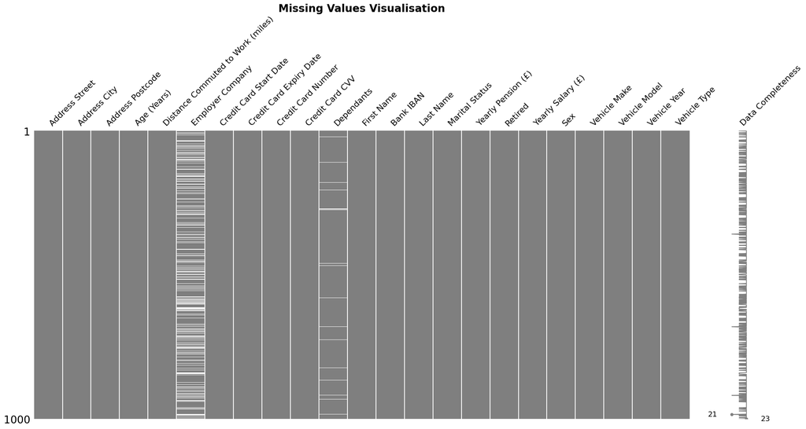

```python
# Use the msno.matrix function from the missingno library to create a visual representation of missing values in the DataFrame
msno.matrix(df, color=(0.5, 0.5, 0.5), labels=True)

# Set the title of the plot with a custom font size and font weight
plt.title('Missing Values Visualisation', fontsize=20, fontweight='bold')

# Display the plot
plt.show()
```

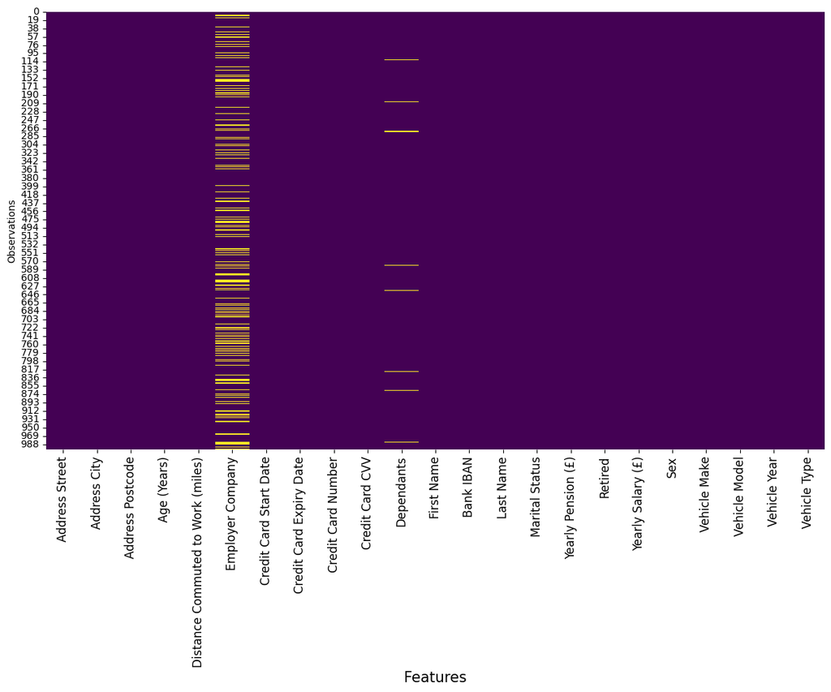

```python
# Create a new figure with a custom size
plt.figure(figsize=(12,10))

# Use the seaborn heatmap function to create a heatmap of the missing values in the DataFrame
sns.heatmap(df.isnull(), cbar=False, cmap='viridis')

# Set the font size for the x-axis tick labels
plt.xticks(fontsize=12)

# Set the x-axis label with a custom font size
plt.xlabel('Features', fontsize=15)

# Set the y-axis label
plt.ylabel('Observations')

# Automatically adjust subplots and labels so that they fit in the figure area
plt.tight_layout()

# Display the plot
plt.show()
```

#### 5. MISSING VALUE VISUALISATION (SELECTED NAN VALUES DATASET)

The code creates a new DataFrame df2 by using boolean indexing to filter the original DataFrame df. The isna() method is used to check for missing values (NaN values) in the DataFrame, and the any(axis=1) argument is used to check if any value in each row is missing. The result is a boolean mask indicating which rows contain missing values.

The filtered DataFrame is then assigned to df2 and now df2 will contain only the rows from df that have missing values.

```python
#Creating new dataset known as df2 or NaN value
df2 = df[df.isna().any(axis=1)]
df2
```

|  | Address Street | Address City | Address Postcode | Age (Years) | Distance Commuted to Work (miles) | Employer Company | Credit Card Start Date | Credit Card Expiry Date | Credit Card Number | Credit Card CVV | ... | Last Name | Marital Status | Yearly Pension (£) | Retired | Yearly Salary (£) | Sex | Vehicle Make | Vehicle Model | Vehicle Year | Vehicle Type |
| --- | --- | --- | --- | --- | --- | --- | --- | --- | --- | --- | --- | --- | --- | --- | --- | --- | --- | --- | --- | --- | --- |
| 0 | 70 Lydia isle | Lake Conor | S71 7XZ | 89 | 0.00 | NaN | 08/18 | 11/27 | 676373692463 | 875 | ... | Wilson | married or civil partner | 7257 | True | 72838 | Male | Hyundai | Bonneville | 2009 | Pickup |
| 7 | 81 Goodwin dam | Griffinstad | G3 7ZX | 67 | 0.00 | NaN | 07/15 | 04/27 | 213199489183130 | 389 | ... | Evans | single | 28075 | True | 27964 | Male | Volvo | Express 3500 Passenger | 2013 | SUV |
| 9 | Studio 77c Gail tunnel | Garyberg | S7W 4DW | 87 | 0.00 | NaN | 10/13 | 10/13 | 213198388220332 | 766 | ... | Hamilton | single | 29587 | True | 66157 | Male | Dodge | Impreza | 2015 | Sedan |
| 14 | 8 Bray row | Daviestown | S2H 5RE | 78 | 0.00 | NaN | 10/12 | 12/19 | 4548406264381245 | 22 | ... | John | married or civil partner | 24712 | True | 59891 | Female | Nissan | LC | 2012 | SUV |
| 21 | 9 Hargreaves loaf | New Keith | OX85 1NN | 40 | 11.98 | Frost-Howard | 09/18 | 02/23 | 3577676608962779 | 426 | ... | Marshall | married or civil partner | 0 | False | 44434 | Female | MAZDA | Tundra Regular Cab | 2001 | Sedan |
| ... | ... | ... | ... | ... | ... | ... | ... | ... | ... | ... | ... | ... | ... | ... | ... | ... | ... | ... | ... | ... | ... |
| 985 | 71 Smith stravenue | Lesleytown | MK0 1HD | 83 | 0.00 | NaN | 08/20 | 11/21 | 38175563559869 | 684 | ... | Mistry | married or civil partner | 16436 | True | 66220 | Male | GMC | Venture Cargo | 2018 | SUV |
| 986 | Studio 51 Scott summit | East Shane | N2 8WH | 90 | 0.00 | NaN | 10/12 | 01/18 | 2711366246819743 | 863 | ... | Thomas | married or civil partner | 25776 | True | 26654 | Male | Kia | 3 Series | 2003 | Coupe, Convertible |
| 988 | Studio 6 Leslie keys | Andreastad | KA4X 1QR | 76 | 0.00 | NaN | 10/17 | 12/28 | 675992264696 | 909 | ... | Goddard | married or civil partner | 28990 | True | 48597 | Male | Scion | Vibe | 2005 | Wagon |
| 994 | Flat 35h Kathleen extensions | Lake Owenmouth | G3 8PL | 90 | 0.00 | NaN | 06/15 | 07/26 | 213131632975005 | 911 | ... | Sykes | single | 15650 | True | 49928 | Male | Nissan | Prizm | 1994 | Van/Minivan |
| 999 | Flat 9 Mohamed route | West Glen | LL3M 4WS | 80 | 0.00 | NaN | 12/14 | 01/16 | 180020306382110 | 903 | ... | Russell | single | 22869 | True | 25788 | Female | Geo | S7 | 1993 | Van/Minivan |

261 rows × 23 columns

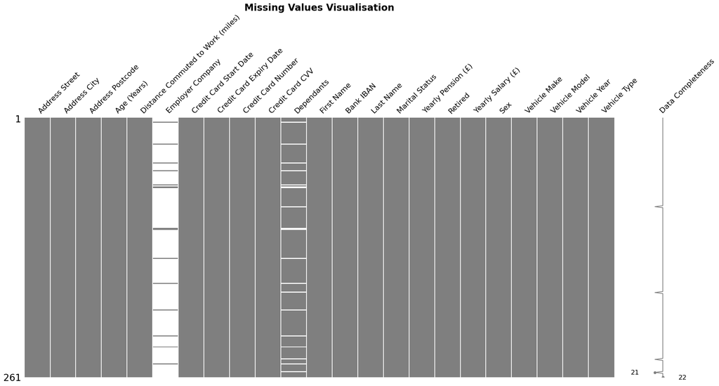

```python
# Use the msno.matrix function from the missingno library to create a visual representation of missing values in the DataFrame
msno.matrix(df2, color=(0.5, 0.5, 0.5), labels=True)

# Set the title of the plot with a custom font size and font weight
plt.title('Missing Values Visualisation', fontsize=20, fontweight='bold')

# Display the plot
plt.show()
```

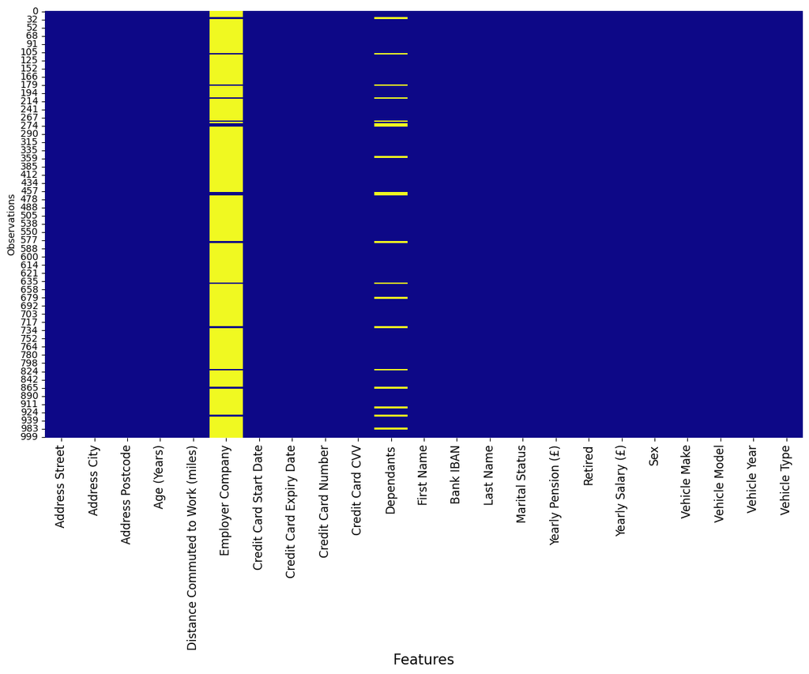

```python
# Create a new figure with a custom size
plt.figure(figsize=(12,10))

# Use the seaborn heatmap function to create a heatmap of the missing values in the DataFrame
sns.heatmap(df2.isnull(), cbar=False, cmap='plasma')

# Set the font size for the x-axis tick labels
plt.xticks(fontsize=12)

# Set the x-axis label with a custom font size
plt.xlabel('Features', fontsize=15)

# Set the y-axis label
plt.ylabel('Observations')

# Automatically adjust subplots and labels so that they fit in the figure area
plt.tight_layout()

# Display the plot
plt.show()
```

#### 6. INSPECTING TOTAL MISSING VALUES

```python
#total missing vlaues on row and columns
total_missing_value = df.isnull().sum().sum()
total_missing_value
```

```
265
```

```python
#row and columns
total_dataset = (df.shape[0] * df.shape[1])
total_dataset
```

```
23000
```

```python
missing_value_ratio = total_missing_value / total_dataset
missing_value_ratio
```

```
0.011521739130434782
```

```python
percentage_missing = missing_value_ratio*100
print(f"Total Missing Value Percentage: {round(percentage_missing,4)}%")
```

```
Total Missing Value Percentage: 1.1522%
```

#### 7. GROUPING OF DATASET

#### Credit card details

```python
credit_detail = pd.DataFrame(df, columns=['Credit Card Number','Credit Card Start Date', 'Credit Card Expiry Date', 'Credit Card CVV', 'Bank IBAN'])
credit_detail
```

|  | Credit Card Number | Credit Card Start Date | Credit Card Expiry Date | Credit Card CVV | Bank IBAN |
| --- | --- | --- | --- | --- | --- |
| 0 | 676373692463 | 08/18 | 11/27 | 875 | GB62PQKB71416034141571 |
| 1 | 4529436854129855 | 08/12 | 11/26 | 583 | GB37UMCO54540228728019 |
| 2 | 4091726363083888495 | 11/19 | 07/27 | 422 | GB40CVUE84011545859591 |
| 3 | 4671332769487632633 | 10/17 | 04/18 | 669 | GB40YPKK71613332239280 |
| 4 | 2245094149128526 | 04/19 | 11/27 | 659 | GB95WAYW31715898077181 |
| ... | ... | ... | ... | ... | ... |
| 995 | 3563802099155576 | 04/19 | 08/26 | 908 | GB45UVZH05043505193524 |
| 996 | 3591311819315276 | 05/12 | 07/28 | 675 | GB88EGZV32518465934497 |
| 997 | 3584931475767707 | 01/13 | 05/29 | 679 | GB81SVHK17718594367943 |
| 998 | 4090311300716168 | 04/19 | 05/23 | 775 | GB14LLBD59118062249339 |
| 999 | 180020306382110 | 12/14 | 01/16 | 903 | GB45ORXV49380519147072 |

1000 rows × 5 columns

```python
credit_detail.shape
```

```
(1000, 5)
```

```python
credit_detail.isnull().sum()
```

```
Credit Card Number         0
Credit Card Start Date     0
Credit Card Expiry Date    0
Credit Card CVV            0
Bank IBAN                  0
dtype: int64
```

```python
credit_detail.dtypes
```

```
Credit Card Number          int64
Credit Card Start Date     object
Credit Card Expiry Date    object
Credit Card CVV             int64
Bank IBAN                  object
dtype: object
```

#### Vehicle details

```python
vehicle = pd.DataFrame(df, columns=['Vehicle Make','Vehicle Model','Vehicle Year','Vehicle Type' ])
vehicle
```

|  | Vehicle Make | Vehicle Model | Vehicle Year | Vehicle Type |
| --- | --- | --- | --- | --- |
| 0 | Hyundai | Bonneville | 2009 | Pickup |
| 1 | Nissan | ATS | 1996 | Coupe |
| 2 | GMC | Achieva | 2015 | Convertible, Coupe |
| 3 | Scion | F150 SuperCrew Cab | 1994 | Pickup |
| 4 | Buick | Outback | 2020 | SUV |
| ... | ... | ... | ... | ... |
| 995 | Saturn | Convertible | 2015 | Van/Minivan |
| 996 | Toyota | Yukon | 2015 | Van/Minivan |
| 997 | Ford | S6 | 2020 | Sedan |
| 998 | Scion | Ram 1500 Quad Cab | 2015 | Pickup |
| 999 | Geo | S7 | 1993 | Van/Minivan |

1000 rows × 4 columns

#### Address details

```python
address = pd.DataFrame(df, columns= ['Address Street', 'Address City', 'Address Postcode'])
address
```

|  | Address Street | Address City | Address Postcode |
| --- | --- | --- | --- |
| 0 | 70 Lydia isle | Lake Conor | S71 7XZ |
| 1 | 00 Wheeler wells | Chapmanton | L2 7BT |
| 2 | Studio 33K Joel walk | Randallborough | ME3N 1GH |
| 3 | Studio 46S Bethany lights | East Reece | E10 9RJ |
| 4 | Flat 3 Christine views | Fletcherstad | WS2 9SN |
| ... | ... | ... | ... |
| 995 | Studio 6 Heather prairie | North Amelia | E9 0HB |
| 996 | Flat 3 Davies run | Greenshire | E7 4UJ |
| 997 | Flat 7 Barber motorway | Burrowsshire | L62 8TA |
| 998 | 00 Tony forks | Abbiebury | NP4 1JL |
| 999 | Flat 9 Mohamed route | West Glen | LL3M 4WS |

1000 rows × 3 columns

1. Folium: a library for creating interactive maps in Python.
2. Basemap: a library for plotting 2D data on maps in Python.
3. Geopandas: a library for working with geospatial data in Python.
4. Plotly: a library for creating interactive visualizations in Python, including maps.

```python
geolocator = Nominatim(user_agent="geoapiExercises")

def get_latitude_longitude(postcode):
    location = geolocator.geocode(postcode)
    if location:
        return location.latitude, location.longitude
    else:
        return None, None

postcodes = address['Address Postcode']

latitudes = []
longitudes = []
for postcode in postcodes:
    latitude, longitude = get_latitude_longitude(postcode)
    if latitude and longitude:
        latitudes.append(latitude)
        longitudes.append(longitude)

print("Latitudes:", latitudes)
print("Longitudes:", longitudes)
```

```
Latitudes: [44.5337672, 51.5093907, 53.244562375, -0.2918826, 42.4451515, 51.5092399, 52.32159, -0.2468656, 46.6980404, 47.3450655, 32.332525849999996, 41.3042415, 30.2548277, -0.2598554, 56.2389634, 53.4835371, 51.0005915, -0.2347464, 53.92833065, 52.196973, 51.2802192, 55.83506, 58.01276, 35.55537…
Longitudes: [-69.6202602, -0.1367165, -0.5136978125, -78.4772908, -76.3002947, -0.3344178, -2.0695, -78.4988547, 28.2300947, 9.6386152, 15.207858568760209, 2.0764174, 120.3971418, -78.5107545, -120.7745111, -2.251251, 4.1589339, -78.4897108, 17.87059529198857, 26.8850798, 8.5957612, -4.2638, -3.8516…
```

#### 1. GEOPANDAS

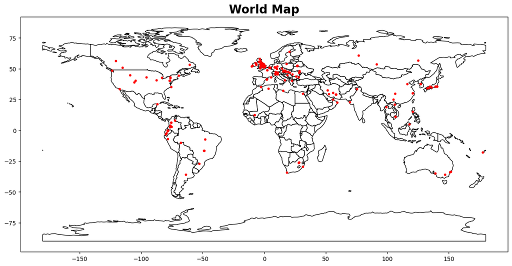

```python
# create a GeoDataFrame from the latitude and longitude lists
geo_df = gpd.GeoDataFrame(data={'latitude': latitudes, 'longitude': longitudes},
                          geometry=gpd.points_from_xy(longitudes, latitudes))

# load a shapefile with geographical data
world = gpd.read_file(gpd.datasets.get_path('naturalearth_lowres'))

# plot the GeoDataFrame on top of the world map
ax = world.plot(figsize=(15, 10), color='white', edgecolor='black')
geo_df.plot(ax=ax, markersize=10, color='red')

# add a title to the plot
plt.title("World Map", fontsize=20, fontweight='bold')

# display the plot
plt.show()
```

#### 2. FOLIUM

```python
# Create a map object centered on the average latitude and longitude
latitude = sum(latitudes)/len(latitudes)
longitude = sum(longitudes)/len(longitudes)
map = folium.Map(location=[latitude, longitude], zoom_start=12)

# Add markers for each latitude and longitude
for lat, lng in zip(latitudes, longitudes):
    folium.Marker(location=[lat, lng]).add_to(map)

# Display the map
map.save('map.html')
```

```python
# Display the map in a Jupyter Notebook
from IPython.display import IFrame
IFrame('map.html', width=1080, height=500)
```

[interactive chart not shown]

#### 3. BASEMAP

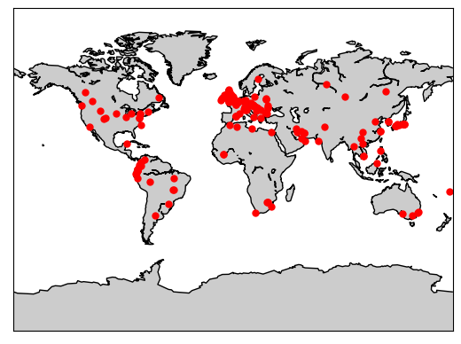

```python
from mpl_toolkits.basemap import Basemap
import matplotlib.pyplot as plt

def plot_on_map(latitudes, longitudes):
    # create the map object
    map = Basemap(projection='mill', lat_0=0, lon_0=0)

    # draw the coastlines and fill the continents
    map.drawcoastlines()
    map.fillcontinents()

    # convert the latitudes and longitudes to map coordinates
    x, y = map(longitudes, latitudes)

    # plot the points on the map
    map.plot(x, y, 'ro', markersize=5)

    # display the plot
    plt.show()

# Example usage
plot_on_map(latitudes, longitudes)
```

#### 4. PLOTLY

```python
def plot_map(latitudes, longitudes):
    fig = px.scatter_mapbox(lat=latitudes, lon=longitudes, zoom=11, height=800)
    fig.update_layout(mapbox_style="open-street-map")
    fig.show()

# Example usage
plot_map(latitudes, longitudes)
```

[interactive chart not shown]

#### Financial details

```python
df.columns
```

```
Index(['Address Street', 'Address City', 'Address Postcode', 'Age (Years)',
       'Distance Commuted to Work (miles)', 'Employer Company',
       'Credit Card Start Date', 'Credit Card Expiry Date',
       'Credit Card Number', 'Credit Card CVV', 'Dependants', 'First Name',
       'Bank IBAN', 'Last Name', 'Marital Status', 'Yearly Pension (£)',
       'Retired', 'Yearly Salary (£)', 'Sex', 'Vehicle Make', 'Vehicle Model',
       'Vehicle Year', 'Vehicle Type'],
      dtype='object')
```

```python
#Total sum of yeraly salary from overall customer
df['Yearly Salary (£)'].sum()
```

```
57814078
```

```python
salary = df['Yearly Salary (£)']
salary.describe()
```

```
count     1000.000000
mean     57814.078000
std      23270.417139
min      17046.000000
25%      39089.750000
50%      57518.000000
75%      77211.500000
max      98915.000000
Name: Yearly Salary (£), dtype: float64
```

```python
#Total sum of Yearly Pension from overall customer
df["Yearly Pension (£)"].sum()
```

```
5875413
```

```python
pension = df["Yearly Pension (£)"]
pension.describe()
```

```
count     1000.000000
mean      5875.413000
std      10986.507761
min          0.000000
25%          0.000000
50%          0.000000
75%          0.000000
max      46117.000000
Name: Yearly Pension (£), dtype: float64
```

### 4. Data Visualisation

#### Univariate plots, also known as univariate visualizations or univariate graphs, are visual representations of a single variable. These plots provide a simple and effective way to understand the distribution, central tendency, and variability of a single variable.

Some common types of univariate plots include:

1. Histograms: A histogram is a bar graph that displays the frequency of occurrences of a set of continuous or discrete data.
2. Box plots: A box plot is a graphical representation of the distribution of a set of data, displaying the median, quartiles, and outliers.
3. Density plots: A density plot is a representation of the distribution of a set of continuous data, showing the density of the data at each point along the scale.
4. Kernel Density Estimation (KDE) Plots: A KDE plot is a smoothed estimate of the distribution of a set of data, showing the distribution of the data as a smooth curve.
5. Bar Plots: A bar plot is a graphical representation of categorical data, showing the frequency of occurrences of each category.
6. Line Plots: A line plot is a graphical representation of continuous data, showing the values of the data over time or along a scale.

Univariate plots are useful for understanding the distribution and variability of a single variable, and can help identify outliers, skewness, and other anomalies in the data. They are also useful for identifying relationships between variables and for selecting appropriate statistical models for analysis.

#### Bivariate plots, also known as bivariate visualizations or bivariate graphs, are visual representations of the relationship between two variables. Bivariate plots are used to explore the relationship between two variables and how they influence each other. In a bivariate plot, each data point is represented as a dot on a two-dimensional graph, with the x-axis representing one variable and the y-axis representing the other. The position of each dot on the graph indicates the values of the two variables for that observation.

Some common types of bivariate plots include:

Scatter Plots: A scatter plot is a graphical representation of the relationship between two variables, showing each data point as a dot on a two-dimensional graph.

Scatter Matrix Plots: A scatter matrix plot is a matrix of scatter plots, showing the relationship between all pairs of variables in a dataset.

Line Plots: A line plot is a graphical representation of the relationship between two continuous variables, showing the values of the data over time or along a scale.

Hexbin Plots: A hexbin plot is a scatter plot where the data points are aggregated and displayed as hexagons, showing the density of the data at each point.

Joint Plots: A joint plot is a bivariate plot that displays the distribution of one variable along the x-axis and the distribution of another variable along the y-axis, and a scatter plot showing the relationship between the two variables.

Bivariate plots can help identify patterns and relationships in the data, including the strength, direction, and form of the relationship. They are also useful for identifying outliers and for selecting appropriate statistical models for analysis.

#### 1. Age count and bin_width of 5

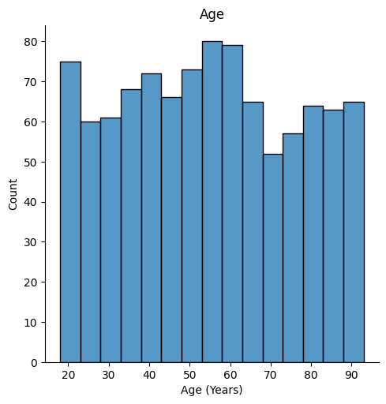

```python
%matplotlib inline
figure_1=sns.displot(data=df, x='Age (Years)', binwidth=5).set(title='Age')
```

It univariate plot that shows the distribution of a single variable. In this case, the variable being plotted is Age (Years), and the plot is a histogram with a binwidth of 5 years. The plot shows the frequency of occurrences of each age value in the dataset, and can help to understand the distribution of ages in the dataset.

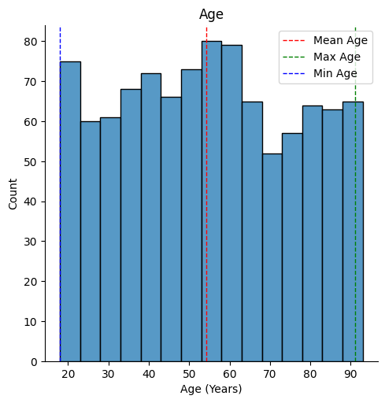

```python
%matplotlib inline
figure_1=sns.displot(data=df, x='Age (Years)', binwidth=5)
mean_age = df["Age (Years)"].mean()
max_age = df["Age (Years)"].max()
min_age = df["Age (Years)"].min()
plt.axvline(mean_age, color='red', linestyle='dashed', linewidth=1, label='Mean Age')
plt.axvline(max_age, color='green', linestyle='dashed', linewidth=1, label='Max Age')
plt.axvline(min_age, color='blue', linestyle='dashed', linewidth=1, label='Min Age')
figure_1.set(title='Age')
plt.legend()
plt.show()
```

```python
# Sort the unique values of the "Age (Years)" column in ascending order
sorted_ages = df['Age (Years)'].sort_values().unique()
print("Sorted Ages:", sorted_ages)
```

```
Sorted Ages: [18 19 20 21 22 23 24 25 26 27 28 29 30 31 32 33 34 35 36 37 38 39 40 41
 42 43 44 45 46 47 48 49 50 51 52 53 54 55 56 57 58 59 60 61 62 63 64 65
 66 67 68 69 70 71 72 73 74 75 76 77 78 79 80 81 82 83 84 85 86 87 88 89
 90 91]
```

```python
mean_age = df["Age (Years)"].mean()
min_age = df["Age (Years)"].max()
max_age = df["Age (Years)"].min()
```

```python
print("Mean age:", mean_age)
print("Min age:", min_age)
print("Max age:", max_age)
```

[output not shown]

1. Highest populated age on dataset are between 52 to 59 year olds
2. Least populated age on dataset are between 68 to 74 year olds

#### 2. Dependants, data fixing errors with seaborn itself

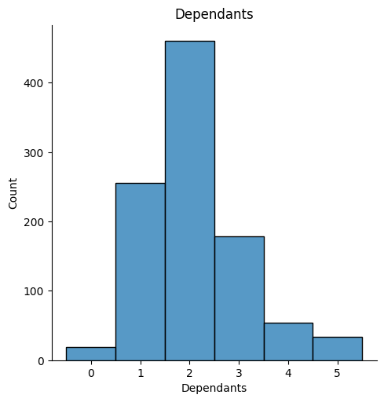

```python
dep = df['Dependants']
dep.fillna(value='0', inplace=True)
dep.isnull().any()
figure_2=sns.displot(data=df, x='Dependants').set(title='Dependants')
```

```python
dependants_count = df['Dependants'].unique()
print("Dependants Count:", dependants_count)
```

```
Dependants Count: [3.0 1.0 2.0 4.0 '0' 5.0]
```

```python
df['Dependants'].value_counts()
```

```
2.0    460
1.0    255
3.0    178
4.0     54
5.0     34
0       19
Name: Dependants, dtype: int64
```

#### 3. Age of default bins, conditioned on Martial status

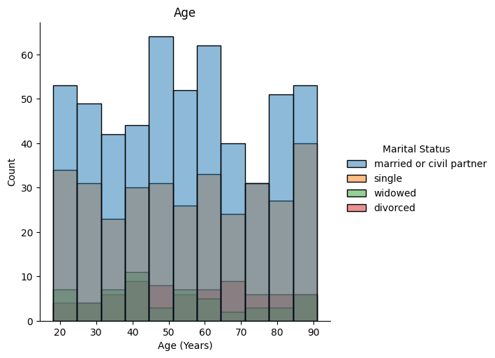

```python
figure_3=sns.displot(data=df, x='Age (Years)', hue='Marital Status').set(title='Age')
```

```python
df['Marital Status'].value_counts()
```

```
married or civil partner    541
single                      330
divorced                     71
widowed                      58
Name: Marital Status, dtype: int64
```

1. Married has highest count 541
2. Widowed has lowest count 58

```python
#Total row in martial status column
len(df['Marital Status'])
```

```
1000
```

```python
print(f'Percentage of married or civil partner customer: {(541/1000)*100}%')
```

```
Percentage of married or civil partner customer: 54.1%
```

```python
print(f'Percentage of single customer: {(330/1000)*100}%')
```

```
Percentage of single customer: 33.0%
```

```python
print(f'Percentage of divorced  customer: {(71/1000)*100}%')
```

```
Percentage of divorced  customer: 7.1%
```

```python
print(f'Percentage of widowed customer: {round((58/1000)*100,2)}%')
```

```
Percentage of widowed customer: 5.8%
```

1. Percentage of married or civil partner customer: 54.1%
2. Percentage of single customer: 33.0%
3. Percentage of divorced customer: 7.1%
4. Percentage of widowed customer: 5.8%

#### 4. Age against salary

#### Original plot

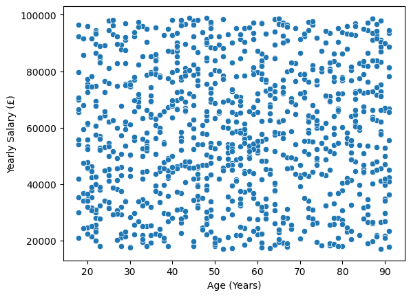

```python
scat_0=sns.scatterplot(data=df, x='Age (Years)', y='Yearly Salary (£)')
```

```python
df.columns
```

```
Index(['Address Street', 'Address City', 'Address Postcode', 'Age (Years)',
       'Distance Commuted to Work (miles)', 'Employer Company',
       'Credit Card Start Date', 'Credit Card Expiry Date',
       'Credit Card Number', 'Credit Card CVV', 'Dependants', 'First Name',
       'Bank IBAN', 'Last Name', 'Marital Status', 'Yearly Pension (£)',
       'Retired', 'Yearly Salary (£)', 'Sex', 'Vehicle Make', 'Vehicle Model',
       'Vehicle Year', 'Vehicle Type'],
      dtype='object')
```